# PERSONAL LOAN CAMPAIGN PROJECT

### Let's use Precision Recall Curve and see if we can find a better threshold

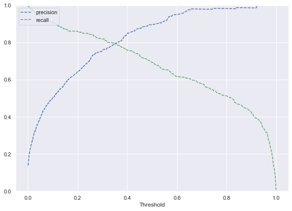

```python
# Let's plot the precision-recall curve to get a balanced threshold
y_scores = lg.predict_proba(X_train)[:, 1]
prec, rec, tre = precision_recall_curve(
    y_train,
    y_scores,
)


def plot_prec_recall_vs_tresh(precisions, recalls, thresholds):
    plt.plot(thresholds, precisions[:-1], "b--", label="precision")
    plt.plot(thresholds, recalls[:-1], "g--", label="recall")
    plt.xlabel("Threshold")
    plt.legend(loc="upper left")
    plt.ylim([0, 1])


plt.figure(figsize=(10, 7))
plot_prec_recall_vs_tresh(prec, rec, tre)
plt.show()
```

#### At 0.35, we get balanced Recall and Precision

```python
# Let's set the threshold to  0.35 and re-run the model
optimal_threshold_curve = 0.35
```

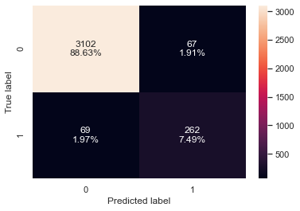

```python
# Creating confusion matrix with the new threhold
confusion_matrix_sklearn_with_threshold(
    lg, X_train, y_train, threshold=optimal_threshold_curve
)
```

```python
# Let's check the performance of the model with the new threshold of 0.35
log_reg_model_train_perf_threshold_curve = (
    model_performance_classification_sklearn_with_threshold(
        lg, X_train, y_train, threshold=optimal_threshold_curve
    )
)
print("Training performance:")
log_reg_model_train_perf_threshold_curve
```

```
Training performance:
```

|  | Accuracy | Recall | Precision | F1 |
| --- | --- | --- | --- | --- |
| 0 | 0.961143 | 0.791541 | 0.796353 | 0.793939 |

#### Observation: It can be observed that Recall and Precision have become balanced

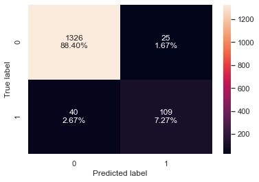

```python
##checking model performance on test set
# creating confusion matrix
confusion_matrix_sklearn_with_threshold(
    lg, X_test, y_test, threshold=optimal_threshold_curve
)
```

```python
# Let's check the model performance on test set
log_reg_model_test_perf_threshold_curve = (
    model_performance_classification_sklearn_with_threshold(
        lg, X_test, y_test, threshold=optimal_threshold_curve
    )
)
print("Test set performance:")
log_reg_model_test_perf_threshold_curve
```

```
Test set performance:
```

|  | Accuracy | Recall | Precision | F1 |
| --- | --- | --- | --- | --- |
| 0 | 0.956667 | 0.731544 | 0.813433 | 0.770318 |

- Model is performing well on training and test.
- There's not much improvement in the model performance as the default threshold is 0.50 and here we get 0.35 as the optimal threshold.

### Model Performance Summary

```python
# Let's tabulate training performance comparison

models_train_comp_df = pd.concat(
    [
        log_reg_model_train_perf.T,
        log_reg_model_train_perf_threshold_auc_roc.T,
        log_reg_model_train_perf_threshold_curve.T,
    ],
    axis=1,
)
models_train_comp_df.columns = [
    "Logistic Regression sklearn",
    "Logistic Regression-0.07 Threshold",
    "Logistic Regression-0.35 Threshold",
]
print("Training performance comparison:")
models_train_comp_df
```

```
Training performance comparison:
```

|  | Logistic Regression sklearn | Logistic Regression-0.07 Threshold | Logistic Regression-0.35 Threshold |
| --- | --- | --- | --- |
| Accuracy | 0.963429 | 0.888286 | 0.961143 |
| Recall | 0.691843 | 0.930514 | 0.791541 |
| Precision | 0.898039 | 0.455621 | 0.796353 |
| F1 | 0.781570 | 0.611718 | 0.793939 |

```python
# testing performance comparison

models_test_comp_df = pd.concat(
    [
        log_reg_model_test_perf.T,
        log_reg_model_test_perf_threshold_auc_roc.T,
        log_reg_model_test_perf_threshold_curve.T,
    ],
    axis=1,
)
models_test_comp_df.columns = [
    "Logistic Regression sklearn",
    "Logistic Regression-0.07 Threshold",
    "Logistic Regression-0.35 Threshold",
]
print("Test set performance comparison:")
models_test_comp_df
```

```
Test set performance comparison:
```

|  | Logistic Regression sklearn | Logistic Regression-0.07 Threshold | Logistic Regression-0.35 Threshold |
| --- | --- | --- | --- |
| Accuracy | 0.958667 | 0.893333 | 0.956667 |
| Recall | 0.644295 | 0.906040 | 0.731544 |
| Precision | 0.914286 | 0.480427 | 0.813433 |
| F1 | 0.755906 | 0.627907 | 0.770318 |

#### Observation: The model with 0.35 threshold also gives good performance on the test set across all metrics